# Using machine-learning to analyse English vowels produced by Chinese learners of English - Part 2: Data Processing

Martin Schweinberger

2024-04-10

# Introduction

This R Notebook shows the statistical analysis of vowel production features of monophthongs produced by Chinese Learners and Native Speakers of English.

## Preparation

install packages

```r
# install
install.packages("tidyverse")
install.packages("here")
install.packages("viridis")
install.packages("phonR")
install.packages("vowels")
install.packages("ggridges")
install.packages("sm")
install.packages("glmmTMB")
```

load packages

```r
library(tidyverse)
library(here)
library(viridis)
library(phonR)
library(vowels)
library(ggridges)
library(sm)
options("scipen" = 100, "digits" = 12) # suppress math annotation
```

load data

```r
# load .rda data
vdf  <- base::readRDS(file = here::here("data", "vdf.rda")) %>%
  dplyr::mutate(type = stringr::str_replace_all(file, "^[A-Z]{2,}_([A-Z]{3,3})_.*", "\\1"),
                speaker = stringr::str_replace_all(file, ".*_([0-9]{3,3})_.*", "\\1")) %>%
  dplyr::mutate(tgender = stringr::str_replace_all(path, ".*F[3-7]{1,1}_([fm]{1,1})_[a-z]{2,2}$", "\\1"),
                tformants = stringr::str_replace_all(path, ".*(F[3-7]{1,1})_[fm]{1,1}_[a-z]{2,2}$", "\\1"),
                tvariety = stringr::str_remove_all(path, ".*_"))
# inspect
nrow(vdf); head(vdf)
```

```
## [1] 402650
```

```
## # A tibble: 6 × 17
## # Rowwise:
##   id     tmin  tmax label word  file      midpoint    F1    F2    F3 vowel path
##   <chr> <dbl> <dbl> <chr> <chr> <chr>        <dbl> <dbl> <dbl> <dbl> <chr> <chr>
## 1 1      2.28  2.52 {     that  SM_CHN_P…     2.40  686. 1412. 2250  æ     F:/d…
## 2 1     13.9  14.1  @     to    SM_CHN_P…    14.0   682. 1355. 1940. ə     F:/d…
## 3 1     18.1  18.3  @     to    SM_CHN_P…    18.2   553. 1510. 2790. ə     F:/d…
## 4 1     19.1  19.2  @     the   SM_CHN_P…    19.2   589. 1423. 2472. ə     F:/d…
## 5 1     20.4  20.5  i:    we    SM_CHN_P…    20.5   524. 2467. 3193. iː    F:/d…
## 6 1     20.7  20.8  Q     got   SM_CHN_P…    20.7   606. 1153. 2308. ɒ     F:/d…
## # ℹ 5 more variables: type <chr>, speaker <chr>, tgender <chr>,
## #   tformants <chr>, tvariety <chr>
```

# Load Biodata

```r
bio <- read.delim(here::here("data", "biodata_icnale.txt"), header = T, sep = "\t") %>%
  dplyr::filter(stringr::str_detect(Code, "CHN|ENS")) %>%
  dplyr::mutate(type = stringr::str_replace_all(Code, "^[A-Z]{2,}_([A-Z]{3,3})_.*", "\\1"),
                speaker = stringr::str_replace_all(Code, ".*_([0-9]{3,3}).*", "\\1"),
                Sex = tolower(Sex)) %>%
  dplyr::rename(gender = Sex)
bio[bio=="N/A"]<-NA
# inspect
head(bio)
```

```
##         Code Country PTJ1..wds. PTJ2..wds. SMK1..wds. SMK2..wds. Self.Ev gender
## 1 SM_CHN_001     CHN         99        129        109        108       1      m
## 2 SM_CHN_002     CHN         52         59         43         49       1      m
## 3 SM_CHN_003     CHN         95        107         90         98       1      m
## 4 SM_CHN_004     CHN         77         81         69         90       0      f
## 5 SM_CHN_005     CHN         95        102         93        102       3      m
## 6 SM_CHN_006     CHN         89         99         98        128       1      f
##   Age Grade.Degree Yrs.of.Stay....Yrs. ENS.Type         Major..Occupation
## 1  20            1                <NA>     <NA>    Mechanical Engineering
## 2  20            2                <NA>     <NA> Nuclear Power Engineering
## 3  19            2                <NA>     <NA>    Mechanical Engineering
## 4  20            3                   1     <NA>   Information Engineering
## 5  19            2                <NA>     <NA>                   Physics
## 6  20            2                <NA>     <NA>                   Finance
##             Acad..Genre Test Score VST CEFR INTM INSM INTM.INSM INTM.INSM.1
```

[output cut: 20 more lines]

# Join data sets

Join formant and biodata

```r
fdat <- dplyr::left_join(vdf, bio, by = c("type", "speaker"))  %>%
  # filter out di- and triphthongs
  dplyr::mutate(nv = nchar(stringr::str_remove_all(label, ":"))) %>%
  dplyr::filter(nv == 1) %>%
  dplyr::filter(gender == tgender) %>%
  # remove  ref speakers with l1-var other than genam or gb
  dplyr::mutate(tvariety = dplyr::case_when(Country == "ENS_GBR" ~ "gb",
                                            Country == "ENS_CAN" ~ "us",
                                            Country == "ENS_USA" ~ "us",
                                             TRUE ~ tvariety)) %>%
  dplyr::filter(type == "CHN" | type == "ENS" & Country == "ENS_CAN" | Country == "ENS_GBR" | Country == "ENS_USA") %>%
  dplyr::filter(Age < 40) %>%
  # clean vowels (remove :)
  dplyr::mutate(vowel = stringr::str_remove_all(vowel, "ː")) %>%
  # add full gender
  dplyr::mutate(gender = dplyr::case_when(gender == "m" ~ "male",
                                          gender == "f" ~ "female",
                                          T ~ gender))
# inspect
head(fdat)
```

```
## # A tibble: 6 × 53
## # Rowwise:
##   id     tmin  tmax label word  file      midpoint    F1    F2    F3 vowel path
##   <chr> <dbl> <dbl> <chr> <chr> <chr>        <dbl> <dbl> <dbl> <dbl> <chr> <chr>
## 1 3      2.28  2.52 {     that  SM_CHN_P…     2.40  698. 1329. 2010. æ     F:/d…
## 2 3     13.9  14.1  @     to    SM_CHN_P…    14.0   675. 1293. 1823. ə     F:/d…
## 3 3     18.1  18.3  @     to    SM_CHN_P…    18.2   544. 1189. 2177. ə     F:/d…
## 4 3     19.1  19.2  @     the   SM_CHN_P…    19.2   590. 1313. 2226. ə     F:/d…
## 5 3     20.4  20.5  i:    we    SM_CHN_P…    20.5   497. 1858. 2989. i     F:/d…
## 6 3     20.7  20.8  Q     got   SM_CHN_P…    20.7   581. 1008. 1739. ɒ     F:/d…
## # ℹ 41 more variables: type <chr>, speaker <chr>, tgender <chr>,
## #   tformants <chr>, tvariety <chr>, Code <chr>, Country <chr>,
## #   PTJ1..wds. <int>, PTJ2..wds. <int>, SMK1..wds. <int>, SMK2..wds. <int>,
## #   Self.Ev <chr>, gender <chr>, Age <int>, Grade.Degree <chr>,
## #   Yrs.of.Stay....Yrs. <chr>, ENS.Type <chr>, Major..Occupation <chr>,
## #   Acad..Genre <chr>, Test <chr>, Score <chr>, VST <chr>, CEFR <chr>,
## #   INTM <chr>, INSM <chr>, INTM.INSM <chr>, INTM.INSM.1 <chr>, …
```

overview

```r
library(janitor)
tb0 <- fdat %>%
  dplyr::ungroup() %>%
  dplyr::group_by(type) %>%
  dplyr::mutate(speakers = length(table(speaker))) %>%
  dplyr::ungroup() %>%
  dplyr::group_by(type, vowel) %>%
  dplyr::summarise(speakers = speakers,
                   obs = n()) %>%
  unique() %>%
  tidyr::spread(vowel, obs) %>%
  dplyr::ungroup()  %>%
  adorn_totals("row")%>%
  adorn_totals("col") %>%
  dplyr::mutate(Total = Total-speakers)
# save
write.table(tb0, here::here("tables", "tb0.txt"), sep = "\t")
# inspect
tb0
```

```
##   type speakers    ɐ  ɑ    ɒ     æ   ɔ    e     ə    ɛ  ɜ     i     ɪ     u
##    CHN      148  750 75 1065  7985 200 2815 23840 2280  5 10175 20755 11045
##    ENS      107  395 20  820  7100  80  790  5550 2810 NA  4925 10140  8725
##  Total      255 1145 95 1885 15085 280 3605 29390 5090  5 15100 30895 19770
##     ʊ     ʌ  Total
##  4905 15125 101020
##  1320  9630  52305
##  6225 24755 153325
```

testing

```r
table(fdat$vowel, fdat$tvariety, fdat$type)
```

```
## , ,  = CHN
##
##
##        gb    us
##   ɐ     0   750
##   ɑ    75     0
##   ɒ   685   380
##   æ  3610  4375
##   ɔ   100   100
##   e  2815     0
##   ə 23305   535
##   ɛ     0  2280
##   ɜ     5     0
##   i  3865  6310
##   ɪ 11385  9370
##   u  1615  9430
##   ʊ  3170  1735
##   ʌ   580 14545
##
## , ,  = ENS
##
##
##        gb    us
##   ɐ     0   395
##   ɑ    20     0
##   ɒ   265   555
##   æ   465  6635
##   ɔ     5    75
##   e   790     0
##   ə  4905   645
##   ɛ     0  2810
##   ɜ     0     0
##   i   500  4425
##   ɪ  1820  8320
##   u   300  8425
##   ʊ   540   780
##   ʌ    65  9565
```

Remove rare vowels

```r
# check
nrow(fdat)
```

```
## [1] 153325
```

```r
# remove
fdat <- fdat %>%
  dplyr::filter(vowel != "ɜ",
                vowel != "ɑ",
                vowel != "ɔ")
# check
nrow(fdat)
```

```
## [1] 152945
```

testing

```r
table(fdat$vowel, fdat$tvariety, fdat$type)
```

```
## , ,  = CHN
##
##
##        gb    us
##   ɐ     0   750
##   ɒ   685   380
##   æ  3610  4375
##   e  2815     0
##   ə 23305   535
##   ɛ     0  2280
##   i  3865  6310
##   ɪ 11385  9370
##   u  1615  9430
##   ʊ  3170  1735
##   ʌ   580 14545
##
## , ,  = ENS
##
##
##        gb    us
##   ɐ     0   395
##   ɒ   265   555
##   æ   465  6635
##   e   790     0
##   ə  4905   645
##   ɛ     0  2810
##   i   500  4425
##   ɪ  1820  8320
##   u   300  8425
##   ʊ   540   780
##   ʌ    65  9565
```

check proficiency

```r
fdat <- fdat %>%
  dplyr::mutate(prof = stringr::str_replace_all(file, ".*_([A-B]{1,1}[0-9]{1,1})_.*", "\\1")) %>%
  mutate(prof = ifelse(prof == file, NA, prof),
         prof = factor(prof, levels = c("A2", "B1", "B2")))
# inspect
summary(fdat$prof)
```

```
##    A2    B1    B2  NA's
##  9770 84340  6630 52205
```

check lables

```r
fdat %>%
  filter(word == "word") %>%
  group_by(label, vowel) %>%
  summarise(freq = n())
```

```
## # A tibble: 0 × 3
## # Groups:   label [0]
## # ℹ 3 variables: label <chr>, vowel <chr>, freq <int>
```

# Reference data

**GenAm**

[Yang, Byunggon. 1996. A comparative study of American English and Korean vowels produced by male and female speakers. *Journal of Phonetics* 24: 245–261.](http://fonetiks.info/bgyang/db/96jp.pdf)

```r
ame <- read.delim(here::here("data/reference", "GenAm.txt"), sep = "\t", header = T) %>%
  dplyr::mutate(label = dplyr::case_when(item == "had" ~ "{",
                                         item == "heed" ~ "i:",
                                         item == "hid" ~ "I",
                                         item == "head" ~ "E",
                                         item == "hard" ~ "6",
                                         item == "whod" ~ "u:",
                                         item == "hood" ~ "U",
                                         item == "hoard" ~ "O:",
                                         item == "hud" ~ "V",
                                         item == "hod" ~ "Q",
                                         TRUE ~ "other"),
                vowel = dplyr::case_when(item == "had" ~ "æ",
                                         item == "heed" ~ "i",
                                         item == "hid" ~ "ɪ",
                                         item == "head" ~ "ɛ",
                                         item == "hard" ~ "ɑ",
                                         item == "whod" ~ "u",
                                         item == "hood" ~ "ʊ",
                                         item == "hoard" ~ "ɔ",
                                         item == "hud" ~ "ʌ",
                                         item == "hod" ~ "ɑ",
                                         TRUE ~ "other"),
                gender = sex) %>%
  dplyr::filter(label != "other",
                vowel != "other") %>%
  dplyr::group_by(label, vowel, gender) %>%
  dplyr::summarise(target_f1 = mean(F1_Hz),
                   target_f2 = mean(F2_Hz),
                   target_f3 = mean(F3_Hz)) %>%
  dplyr::mutate(tvariety = "us")
# inspect data
head(ame)
```

```
## # A tibble: 6 × 7
## # Groups:   label, vowel [3]
##   label vowel gender target_f1 target_f2 target_f3 tvariety
##   <chr> <chr> <chr>      <dbl>     <dbl>     <dbl> <chr>
## 1 6     ɑ     female      769.     1278.     2546. us
## 2 6     ɑ     male        639.     1059.     2323. us
## 3 E     ɛ     female      513.     2559.     2987. us
## 4 E     ɛ     male        473.     2073.     2655. us
## 5 I     ɪ     female      463.     2343.     3011. us
## 6 I     ɪ     male        405.     2026.     2673. us
```

**SSB**

[Deterding, David 2009. The Formants of Monophthong Vowels in Standard Southern British English Pronunciation. *Journal of the International Phonetic Association* 27, 1-2: 47-55. doi:10.1017/S0025100300005417](http://journals.cambridge.org/download.php?file=%2F7775_45AD5CD7849D3B7634A613DE6E61C294_journals__IPA_IPA27_1-2_S0025100300005417a.pdf&cover=Y&code=0639c34593b21cb18a9e7b504bdd5319)

```r
bre <- read.delim(here::here("data/reference", "SSB.txt"), sep = "\t", header = T) %>%
  dplyr::mutate(label = dplyr::case_when(item == "had" ~ "{",
                                         item == "heed" ~ "i:",
                                         item == "hid" ~ "I",
                                         item == "head" ~ "e",
                                         item == "hard" ~ "A:",
                                         item == "whod" ~ "u:",
                                         item == "hood" ~ "U",
                                         item == "hoard" ~ "O:",
                                         item == "hud" ~ "V",
                                         item == "hod" ~ "Q",
                                         TRUE ~ "other"),
                vowel = dplyr::case_when(item == "had" ~ "æ",
                                         item == "heed" ~ "i",
                                         item == "hid" ~ "ɪ",
                                         item == "head" ~ "ɛ",
                                         item == "hard" ~ "ɑ",
                                         item == "whod" ~ "u",
                                         item == "hood" ~ "ʊ",
                                         item == "hoard" ~ "ɔ",
                                         item == "hud" ~ "ʌ",
                                         item == "hod" ~ "ɑ",
                                         TRUE ~ "other"),
                gender = dplyr::case_when(sex == "female" ~ "f",
                                          TRUE ~ "m")) %>%
  dplyr::filter(label != "other",
                vowel != "other") %>%
  dplyr::group_by(label, vowel, gender) %>%
  dplyr::summarise(target_f1 = mean(F1_Hz),
                   target_f2 = mean(F2_Hz),
                   target_f3 = mean(F3_Hz)) %>%
  dplyr::mutate(tvariety = "gb")
# inspect data
head(bre)
```

```
## # A tibble: 6 × 7
## # Groups:   label, vowel [3]
##   label vowel gender target_f1 target_f2 target_f3 tvariety
##   <chr> <chr> <chr>      <dbl>     <dbl>     <dbl> <chr>
## 1 A:    ɑ     f           910.     1316.     2841. gb
## 2 A:    ɑ     m           646.     1155.     2490. gb
## 3 I     ɪ     f           384.     2174.     2962. gb
## 4 I     ɪ     m           367.     1757.     2556  gb
## 5 O:    ɔ     f           389.      888.     2796  gb
## 6 O:    ɔ     m           415.      828.     2619. gb
```

Combine reference and obs data

```r
ref <- rbind(ame, bre)
fdat <- dplyr::left_join(fdat, ref) %>%
  dplyr::filter(!is.na(target_f1)) %>%
  dplyr::mutate(edist = sqrt((F1-target_f1)^2 + (F2-target_f2)^2))
# inspect
head(fdat)
```

```
## # A tibble: 6 × 58
## # Rowwise:
##   id     tmin  tmax label word  file      midpoint    F1    F2    F3 vowel path
##   <chr> <dbl> <dbl> <chr> <chr> <chr>        <dbl> <dbl> <dbl> <dbl> <chr> <chr>
## 1 4      2.29   2.5 {     that  SM_CHN_P…     2.39  714. 1357. 2004. æ     F:/d…
## 2 4     15.1   15.2 u:    to    SM_CHN_P…    15.2   571. 1339. 2818. u     F:/d…
## 3 4     18.2   18.4 u:    to    SM_CHN_P…    18.3   533. 1117. 2053. u     F:/d…
## 4 4     19.0   19.1 V     the   SM_CHN_P…    19.1   509.  920. 1946. ʌ     F:/d…
## 5 4     20.4   20.5 i:    we    SM_CHN_P…    20.5   497. 1858. 2989. i     F:/d…
## 6 4     20.9   21   V     the   SM_CHN_P…    21.0   599.  951. 1995. ʌ     F:/d…
## # ℹ 46 more variables: type <chr>, speaker <chr>, tgender <chr>,
## #   tformants <chr>, tvariety <chr>, Code <chr>, Country <chr>,
## #   PTJ1..wds. <int>, PTJ2..wds. <int>, SMK1..wds. <int>, SMK2..wds. <int>,
## #   Self.Ev <chr>, gender <chr>, Age <int>, Grade.Degree <chr>,
## #   Yrs.of.Stay....Yrs. <chr>, ENS.Type <chr>, Major..Occupation <chr>,
## #   Acad..Genre <chr>, Test <chr>, Score <chr>, VST <chr>, CEFR <chr>,
## #   INTM <chr>, INSM <chr>, INTM.INSM <chr>, INTM.INSM.1 <chr>, …
```

Determine best fit

```r
# check
nrow(fdat)
```

```
## [1] 87550
```

```r
# check minimum distance
fdat <- fdat %>%
  dplyr::arrange(file, tmin, tvariety, tformants) %>%
  dplyr::group_by(file, tmin) %>%
  dplyr::slice(which.min(edist))
# inspect
nrow(fdat); head(fdat)
```

```
## [1] 17510
```

```
## # A tibble: 6 × 58
## # Groups:   file, tmin [6]
##   id     tmin  tmax label word  file      midpoint    F1    F2    F3 vowel path
##   <chr> <dbl> <dbl> <chr> <chr> <chr>        <dbl> <dbl> <dbl> <dbl> <chr> <chr>
## 1 4      2.29   2.5 {     that  SM_CHN_P…     2.39  714. 1357. 2004. æ     F:/d…
## 2 4     15.1   15.2 u:    to    SM_CHN_P…    15.2   571. 1339. 2818. u     F:/d…
## 3 4     18.2   18.4 u:    to    SM_CHN_P…    18.3   533. 1117. 2053. u     F:/d…
## 4 4     19.0   19.1 V     the   SM_CHN_P…    19.1   509.  920. 1946. ʌ     F:/d…
## 5 8     20.4   20.5 i:    we    SM_CHN_P…    20.5   497. 2031. 3021. i     F:/d…
## 6 4     20.9   21   V     the   SM_CHN_P…    21.0   599.  951. 1995. ʌ     F:/d…
## # ℹ 46 more variables: type <chr>, speaker <chr>, tgender <chr>,
## #   tformants <chr>, tvariety <chr>, Code <chr>, Country <chr>,
## #   PTJ1..wds. <int>, PTJ2..wds. <int>, SMK1..wds. <int>, SMK2..wds. <int>,
## #   Self.Ev <chr>, gender <chr>, Age <int>, Grade.Degree <chr>,
## #   Yrs.of.Stay....Yrs. <chr>, ENS.Type <chr>, Major..Occupation <chr>,
## #   Acad..Genre <chr>, Test <chr>, Score <chr>, VST <chr>, CEFR <chr>,
## #   INTM <chr>, INSM <chr>, INTM.INSM <chr>, INTM.INSM.1 <chr>, …
```

remove non-target words (too many characters plus the)

```r
# reduce words
fdat <- fdat %>%
  dplyr::filter(nchar(word) < 9,
                word != "the") %>%
  # bark normalization
  dplyr::mutate(barkF1 = normBark(F1),
                barkF2 = normBark(F2)) %>%
  # lobanov normalization
  dplyr::ungroup() %>%
  dplyr::mutate(fspeaker = paste0(type, speaker, collaspe = "")) %>%
  dplyr::group_by(type, gender, tvariety) %>%
  dplyr::mutate(lobF1 = scale(F1),
                lobF2 = scale(F2)) %>%
  # remove superfluous columns
  dplyr::select(-path, -PTJ1..wds., -PTJ2..wds., -SMK1..wds., -SMK2..wds., -Self.Ev,
                -Grade.Degree, -Acad..Genre, -VST, -CEFR, -INTM, -INSM, -INTM.INSM,
                -INTM.INSM.1, -Primary, -Secondary, -College, -Inschool, -Outschool,
                -Reading, -Writing, -NS, -Presentation, -EssayW, -nv,
                -Yrs.of.Stay....Yrs., -Test, -Score, -ENS.Type,
                -Major..Occupation)
# inspect
head(fdat)
```

```
## # A tibble: 6 × 33
## # Groups:   type, gender, tvariety [1]
##   id     tmin  tmax label word  file      midpoint    F1    F2    F3 vowel type
##   <chr> <dbl> <dbl> <chr> <chr> <chr>        <dbl> <dbl> <dbl> <dbl> <chr> <chr>
## 1 4      2.29   2.5 {     that  SM_CHN_P…     2.39  714. 1357. 2004. æ     CHN
## 2 4     15.1   15.2 u:    to    SM_CHN_P…    15.2   571. 1339. 2818. u     CHN
## 3 4     18.2   18.4 u:    to    SM_CHN_P…    18.3   533. 1117. 2053. u     CHN
## 4 8     20.4   20.5 i:    we    SM_CHN_P…    20.5   497. 2031. 3021. i     CHN
## 5 8     24.2   24.3 I     with  SM_CHN_P…    24.2   439  1234. 2660. ɪ     CHN
## 6 4     35.4   35.5 I     we    SM_CHN_P…    35.5   663. 1165. 1936  ɪ     CHN
## # ℹ 21 more variables: speaker <chr>, tgender <chr>, tformants <chr>,
## #   tvariety <chr>, Code <chr>, Country <chr>, gender <chr>, Age <int>,
## #   Listening <chr>, Speaking <chr>, Pronunciation <chr>, prof <fct>,
## #   target_f1 <dbl>, target_f2 <dbl>, target_f3 <dbl>, edist <dbl>,
## #   barkF1 <dbl>, barkF2 <dbl>, fspeaker <chr>, lobF1 <dbl[,1]>,
## #   lobF2 <dbl[,1]>
```

# (Semi-)Manual cross-evaluation

check for inconsistencies

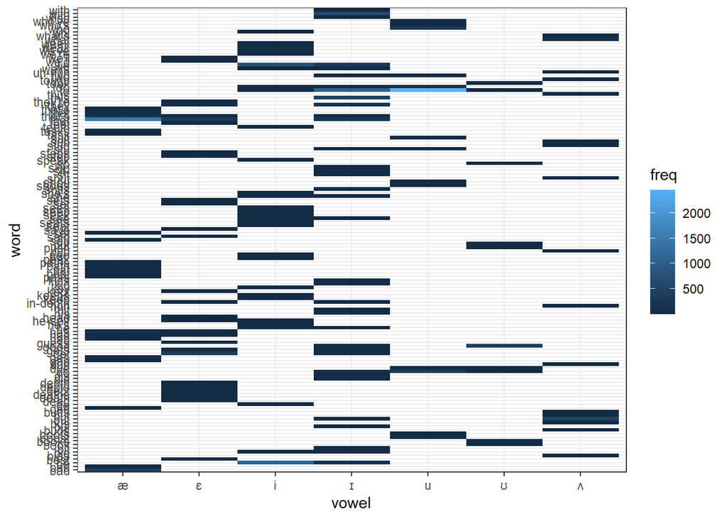

```r
fdat %>%
  dplyr::group_by(word, vowel) %>%
  dplyr::summarise(freq = n()) %>%
  ggplot(aes(y = word, x = vowel, fill = freq)) +
  geom_tile() +
  theme_bw()
```

exclude inconsistencies

```r
fdat <- fdat %>%
  dplyr::mutate(word = stringr::str_remove_all(word, "\\W")) %>%
  dplyr::mutate(remove = dplyr::case_when(word == "bias"  ~ "remove",
                                          word == "bui"  ~ "remove",
                                          word == "da"  ~ "remove",
                                          word == "di"  ~ "remove",
                                          word == "de"  ~ "remove",
                                          word == "dis"  ~ "remove",
                                          word == "due"  ~ "remove",
                                          word == "duh"  ~ "remove",
                                          word == "ha"  ~ "remove",
                                          word == "hab"  ~ "remove",
                                          word == "hes"  ~ "remove",
                                          word == "heself"  ~ "remove",
                                          word == "huh"  ~ "remove",
                                          word == "indepth"  ~ "remove",
                                          word == "pe"  ~ "remove",
                                          word == "po"  ~ "remove",
                                          word == "peo"  ~ "remove",
                                          word == "stu"  ~ "remove",
                                          word == "sub"  ~ "remove",
                                          word == "shou"  ~ "remove",
                                          word == "ta"  ~ "remove",
                                          word == "theyre"  ~ "remove",
                                          word == "they"  ~ "remove",
                                          word == "uhhuh"  ~ "remove",
                                          word == "ways"  ~ "remove",
                                          word == "wed"  ~ "remove",
                                          word == "were"  ~ "remove",
                                          word == "weve"  ~ "remove",
                                          word == "whi"  ~ "remove",
                                          word == "whove"  ~ "remove",

                                          word == "books" & vowel == "ɪ" ~ "remove",
                                          word == "bit" & vowel == "ɐ" ~ "remove",
                                          word == "do" & vowel == "ɐ" ~ "remove",
                                          word == "do" & vowel == "ɪ" ~ "remove",
                                          word == "but" & vowel == "ɪ" ~ "remove",
                                          word == "gas" & vowel == "ɪ" ~ "remove",
                                          word == "get" & vowel == "ɪ" ~ "remove",
                                          word == "gets" & vowel == "ɪ" ~ "remove",
                                          word == "good" & vowel == "ɪ" ~ "remove",
                                          word == "to" & vowel == "ɐ" ~ "remove",
                                          word == "to" & vowel == "ɪ" ~ "remove",
                                          word == "to" & vowel == "iː" ~ "remove",
                                          word == "that" & vowel == "ɪ" ~ "remove",
                                          word == "thats" & vowel == "ɪ" ~ "remove",
                                          word == "too" & vowel == "ɐ" ~ "remove",
                                          word == "too" & vowel == "ɪ" ~ "remove",
                                          word == "too" & vowel == "iː" ~ "remove",
                                          word == "two" & vowel == "ɐ" ~ "remove",
                                          word == "two" & vowel == "ɪ" ~ "remove",
                                          TRUE ~ "keep")) %>%
  dplyr::filter(remove != "remove")
table(fdat$vowel, fdat$word)
```

```
##
##      bad   be best  big  bit book books boost boots buds  bus  but butts  dad
##   æ  367    0    0    0    0    0     0     0     0    0    0    0     0    2
##   ɛ    0    0   33    0    0    0     0     0     0    0    0    0     0    0
##   i    0 1085    0    1    0    0     0     0     0    0    0    0     0    0
##   ɪ    0  142    0   26   18    0     0     0     0    0    0    0     0    0
##   u    0    0    0    0    0    0     0     1     1    0    0    0     0    0
##   ʊ    0    0    0    0    0   10    26     0     0    0    0    0     0    0
##   ʌ    0    0    0    0    0    0     0     0     0    4    1  506     2    0
##
##     dead death deaths debt debts depth  did   do  gap  gas  get gets good guess
##   æ    0     0      0    0     0     0    0    0    1    5    0    0    0     0
##   ɛ    3     8      3   37     2     1    0    0    0    0  322   12    0    27
##   i    0     0      0    0     0     0    0    0    0    0    0    0    0     0
##   ɪ    0     0      0    0     0     0   14    0    0    0    0    0    0     0
##   u    0     0      0    0     0     0    0  373    0    0    0    0    0     0
##   ʊ    0     0      0    0     0     0    0    1    0    0    0    0  411     0
##   ʌ    0     0      0    0     0     0    0    0    0    0    0    0    0     0
##
##      had  has   he head  his  hit keep keeps kept  key  kid kids pass past  pat
##   æ   34  138    0    0    0    0    0     0    0    0    0    0    2    6    1
##   ɛ   13   17    0    2    0    0    0     0    2    0    0    0    0    0    0
##   i    0    0  108    0    0    0   49     1    0    1    0    0    0    0    0
##   ɪ    0    0    8    0   78    1    0     0    0    0    2   11    0    0    0
##   u    0    0    0    0    0    0    0     0    0    0    0    0    0    0    0
##   ʊ    0    0    0    0    0    0    0     0    0    0    0    0    0    0    0
##   ʌ    0    0    0    0    0    0    0     0    0    0    0    0    0    0    0
##
##     path paths peak  pub push  put  sad said  sat says seat seats  see seek
##   æ    2     1    0    0    0    0    2    0    2    0    0     0    0    0
##   ɛ    0     0    0    0    0    0    0   51    0    8    0     0    0    0
##   i    0     0    1    0    0    0    0    0    0    0    2     4   60    1
##   ɪ    0     0    0    0    0    0    0    0    0    0    0     0    1    0
##   u    0     0    0    0    0    0    0    0    0    0    0     0    0    0
##   ʊ    0     0    0    0    2   30    0    0    0    0    0     0    0    0
##   ʌ    0     0    0    2    0    0    0    0    0    0    0     0    0    0
##
##     seep sees  set sets  she shes shits shoes shut  sit skip   so speak step
##   æ    0    0    0    0    0    0     0     0    0    0    0    0     0    0
##   ɛ    0    0    9    2    0    0     0     0    0    0    0    0     0   22
```

[output cut: 8 more lines]

```
##   ɛ     1    0    0    0     0     0    2  302     1    0    0    0    0    0
##   i     0    0    0    0     0     4    0    0     0    0    0   12    2    0
##   ɪ     0    0    0    0     0     0    0    0     0  489    0    0    0    0
##   u     0    0    1    0     0     0    0    0     0    0    0 2453   57    0
##   ʊ     0    0    0    0     0     0    0    0     0    0    0   15    0    6
##   ʌ     0    2    0    0     0     0    0    0     0    0    5    0    0    0
##
##     tough  two   we weak week well what whats  who whos wish with
##   æ     0    0    0    0    0    0    0     0    0    0    0    0
##   ɛ     0    0    0    0    0    1    0     0    0    0    0    0
##   i     0    0  745    9    4    0    0     0    0    0    0    0
##   ɪ     0    0  307    0    0    0    0     0    0    0    9  674
##   u     0   37    0    0    0    0    0     0  341    2    0    0
##   ʊ     0    0    0    0    0    0    0     0    0    0    0    0
##   ʌ     6    0    0    0    0    0  179     9    0    0    0    0
```

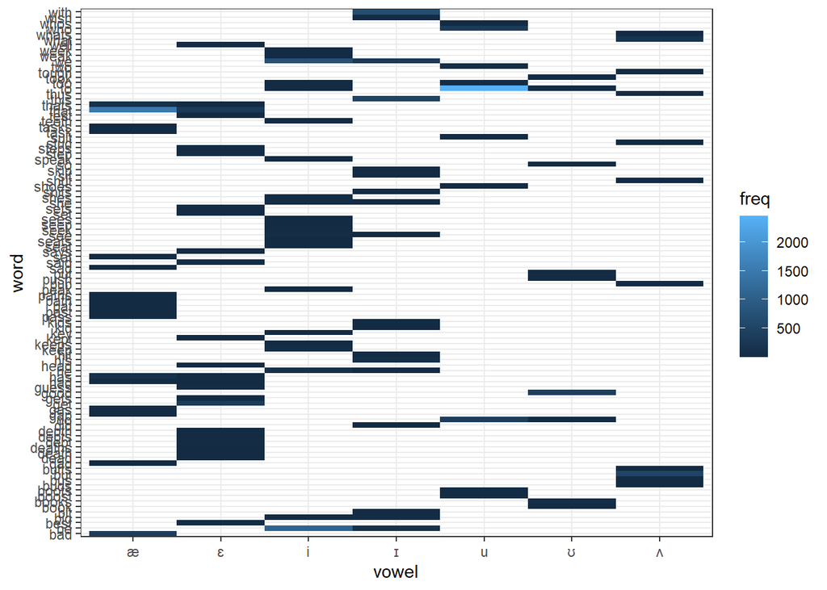

```r
fdat %>%
  dplyr::group_by(word, vowel) %>%
  dplyr::summarise(freq = n()) %>%
  ggplot(aes(y = word, x = vowel, fill = freq)) +
  geom_tile() +
  theme_bw()
```

## Check durations

```r
fdat <- fdat %>%
  # duration
  dplyr::mutate(duration = tmax - tmin)
# inspect
head(fdat)
```

```
## # A tibble: 6 × 35
## # Groups:   type, gender, tvariety [1]
##   id     tmin  tmax label word  file      midpoint    F1    F2    F3 vowel type
##   <chr> <dbl> <dbl> <chr> <chr> <chr>        <dbl> <dbl> <dbl> <dbl> <chr> <chr>
## 1 4      2.29   2.5 {     that  SM_CHN_P…     2.39  714. 1357. 2004. æ     CHN
## 2 4     15.1   15.2 u:    to    SM_CHN_P…    15.2   571. 1339. 2818. u     CHN
## 3 4     18.2   18.4 u:    to    SM_CHN_P…    18.3   533. 1117. 2053. u     CHN
## 4 8     20.4   20.5 i:    we    SM_CHN_P…    20.5   497. 2031. 3021. i     CHN
## 5 8     24.2   24.3 I     with  SM_CHN_P…    24.2   439  1234. 2660. ɪ     CHN
## 6 4     35.4   35.5 I     we    SM_CHN_P…    35.5   663. 1165. 1936  ɪ     CHN
## # ℹ 23 more variables: speaker <chr>, tgender <chr>, tformants <chr>,
## #   tvariety <chr>, Code <chr>, Country <chr>, gender <chr>, Age <int>,
## #   Listening <chr>, Speaking <chr>, Pronunciation <chr>, prof <fct>,
## #   target_f1 <dbl>, target_f2 <dbl>, target_f3 <dbl>, edist <dbl>,
## #   barkF1 <dbl>, barkF2 <dbl>, fspeaker <chr>, lobF1 <dbl[,1]>,
## #   lobF2 <dbl[,1]>, remove <chr>, duration <dbl>
```

plot durations

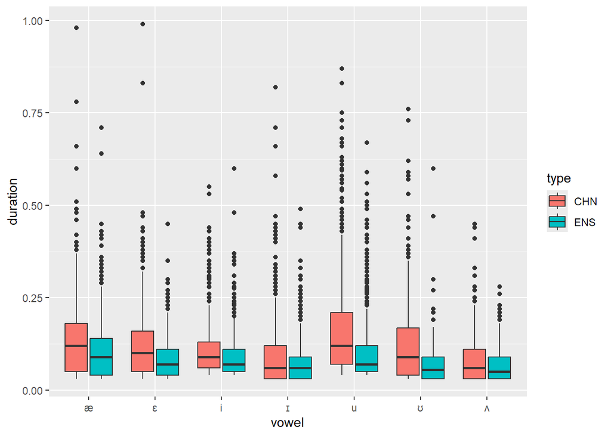

```r
fdat %>%
  ggplot(aes(x = vowel, y = duration, fill = type)) +
  geom_boxplot()
```

```r
max_durs <- fdat %>%
  dplyr::group_by(type, tvariety, vowel) %>%
  dplyr::summarise(du_min = min(duration),
                   du_max = max(duration),
                   du_ave = mean(duration),
                   du_med = median(duration),
                   du_sd = sd(duration),
                   du_2sd = sd(duration)*1.645) %>%
  dplyr::mutate(cutoff_duration = du_ave + du_2sd) %>%
  dplyr::select(type, tvariety, vowel, cutoff_duration)
# inspect
head(max_durs)
```

```
## # A tibble: 6 × 4
## # Groups:   type, tvariety [1]
##   type  tvariety vowel cutoff_duration
##   <chr> <chr>    <chr>           <dbl>
## 1 CHN   us       i               0.227
## 2 CHN   us       u               0.350
## 3 CHN   us       æ               0.293
## 4 CHN   us       ɛ               0.301
## 5 CHN   us       ɪ               0.215
## 6 CHN   us       ʊ               0.325
```

remove duration outliers

```r
fdat <- dplyr::left_join(fdat, max_durs) %>%
  dplyr::filter(duration <= cutoff_duration,
                ifelse(label != "A:", duration <= 0.4, duration <= 0.75))
# inspect
head(fdat); nrow(fdat)
```

```
## # A tibble: 6 × 36
## # Groups:   type, gender, tvariety [1]
##   id     tmin  tmax label word  file      midpoint    F1    F2    F3 vowel type
##   <chr> <dbl> <dbl> <chr> <chr> <chr>        <dbl> <dbl> <dbl> <dbl> <chr> <chr>
## 1 4      2.29   2.5 {     that  SM_CHN_P…     2.39  714. 1357. 2004. æ     CHN
## 2 4     15.1   15.2 u:    to    SM_CHN_P…    15.2   571. 1339. 2818. u     CHN
## 3 4     18.2   18.4 u:    to    SM_CHN_P…    18.3   533. 1117. 2053. u     CHN
## 4 8     20.4   20.5 i:    we    SM_CHN_P…    20.5   497. 2031. 3021. i     CHN
## 5 8     24.2   24.3 I     with  SM_CHN_P…    24.2   439  1234. 2660. ɪ     CHN
## 6 4     35.4   35.5 I     we    SM_CHN_P…    35.5   663. 1165. 1936  ɪ     CHN
## # ℹ 24 more variables: speaker <chr>, tgender <chr>, tformants <chr>,
## #   tvariety <chr>, Code <chr>, Country <chr>, gender <chr>, Age <int>,
## #   Listening <chr>, Speaking <chr>, Pronunciation <chr>, prof <fct>,
## #   target_f1 <dbl>, target_f2 <dbl>, target_f3 <dbl>, edist <dbl>,
## #   barkF1 <dbl>, barkF2 <dbl>, fspeaker <chr>, lobF1 <dbl[,1]>,
## #   lobF2 <dbl[,1]>, remove <chr>, duration <dbl>, cutoff_duration <dbl>
```

```
## [1] 10754
```

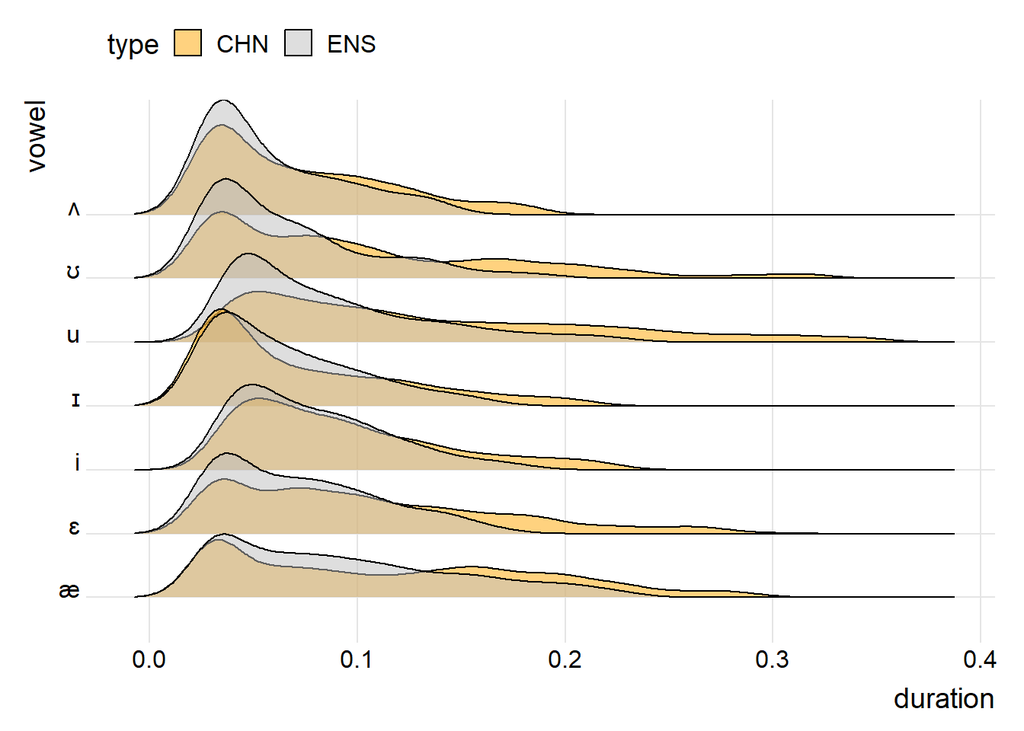

```r
dur_IiUu <-  fdat %>%
  ggplot(aes(y = vowel, x = duration, fill = type)) +
  geom_density_ridges(alpha = .5) +
  theme_ridges() +
  theme(legend.position = "top") +
  scale_fill_manual(values = c("orange", "gray"))
ggsave(here::here("images", "dur_IiUu.png"), height = 3,  width = 5, dpi = 320)
dur_IiUu
```

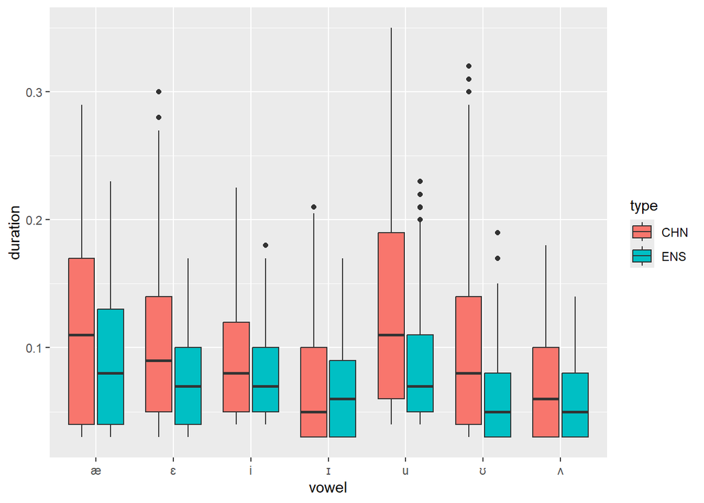

```r
fdat %>%
  ggplot(aes(x = vowel, y = duration, fill = type)) +
  geom_boxplot()
```

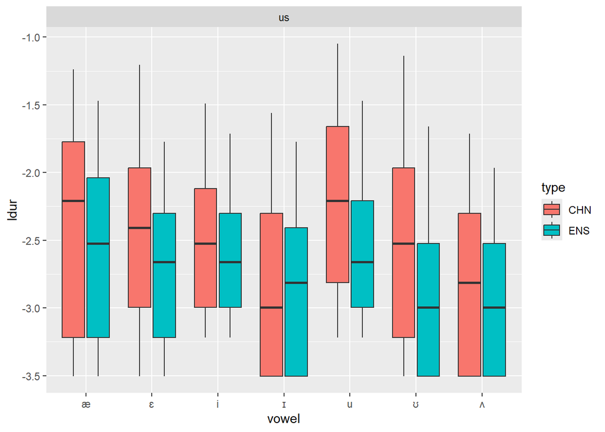

```r
fdat %>%
  dplyr::group_by(type, tvariety, vowel) %>%
  dplyr::mutate(ldur = log(duration)) %>%
  ggplot(aes(x = vowel, y = ldur, fill = type)) +
  geom_boxplot() +
  facet_grid(~tvariety)
```

# Remove outliers

```r
nrow(fdat)
```

```
## [1] 10754
```

```r
fdat <- fdat %>%
  dplyr::group_by(type, tvariety, label) %>%
  dplyr::mutate(densF1 = sm.density(barkF1,eval.points=barkF1)$estimate,
                densF2 = sm.density(barkF2,eval.points=barkF2)$estimate,
                qnt1F1 = quantile(densF1, .5, na.rm = T),
                qnt1F2 = quantile(densF2, .5, na.rm = T))
```

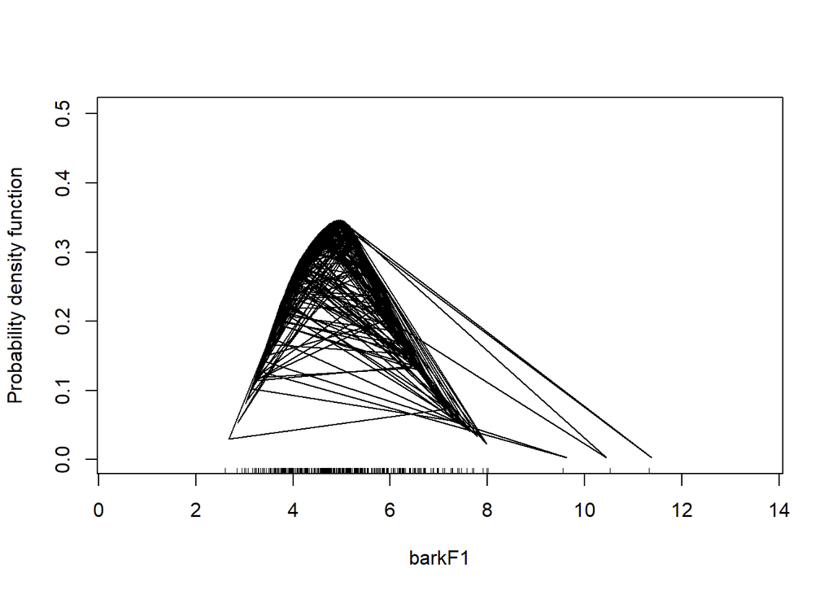

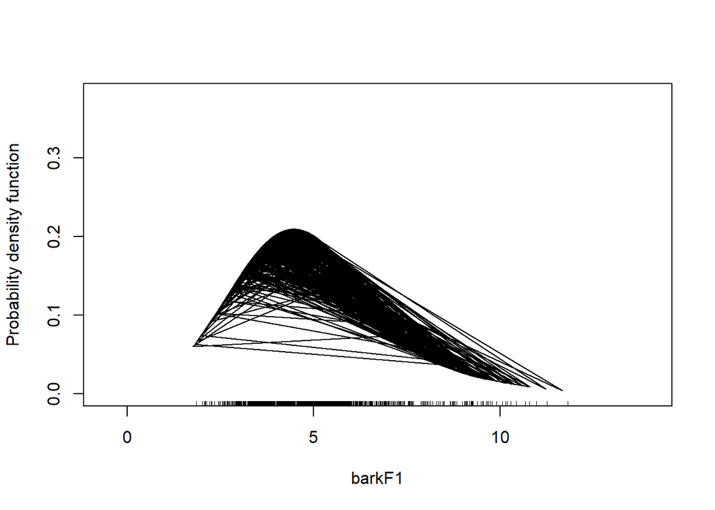

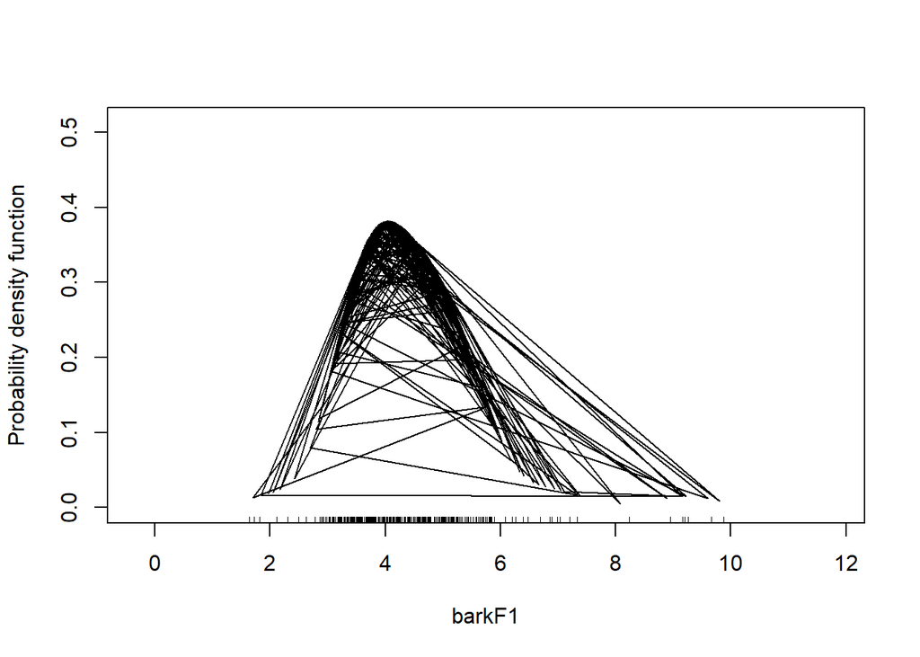

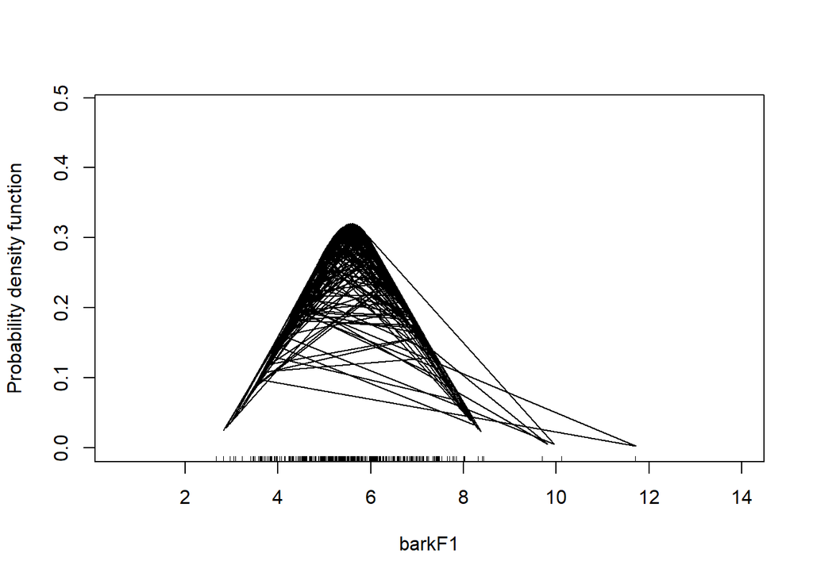

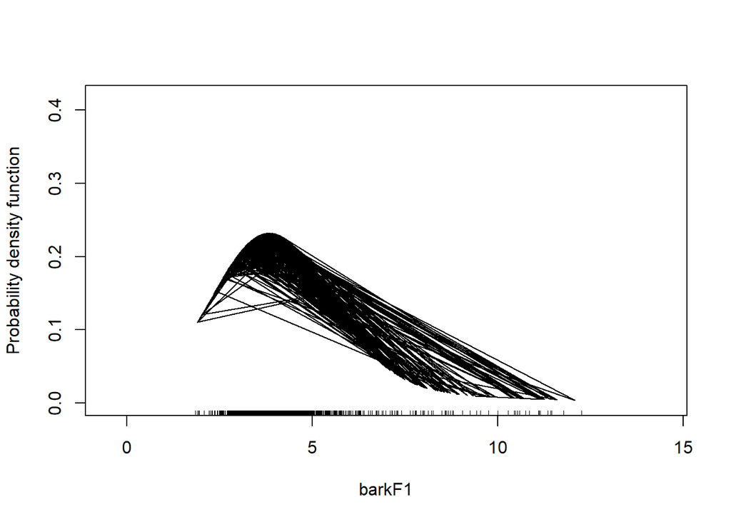

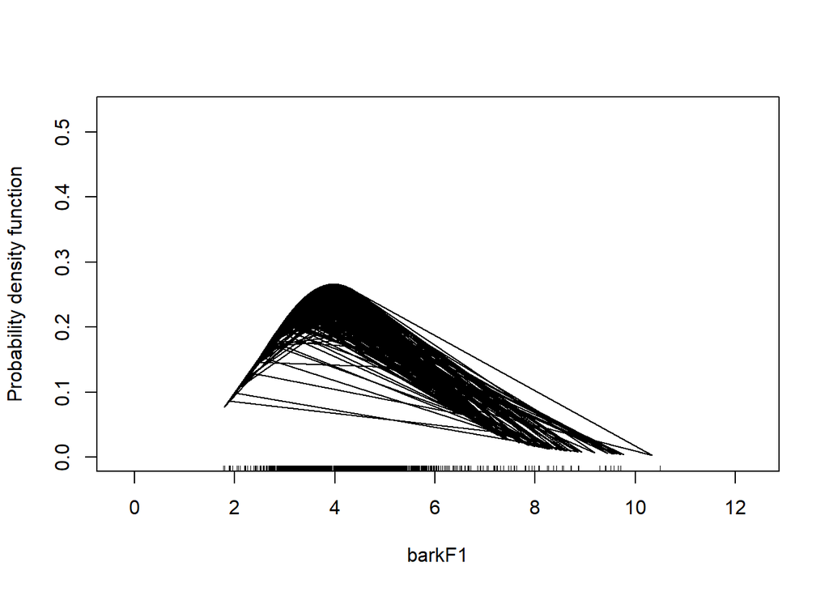

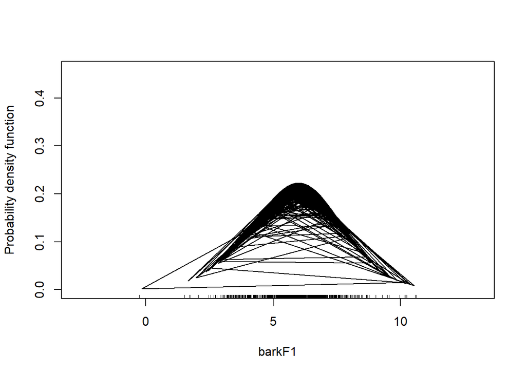

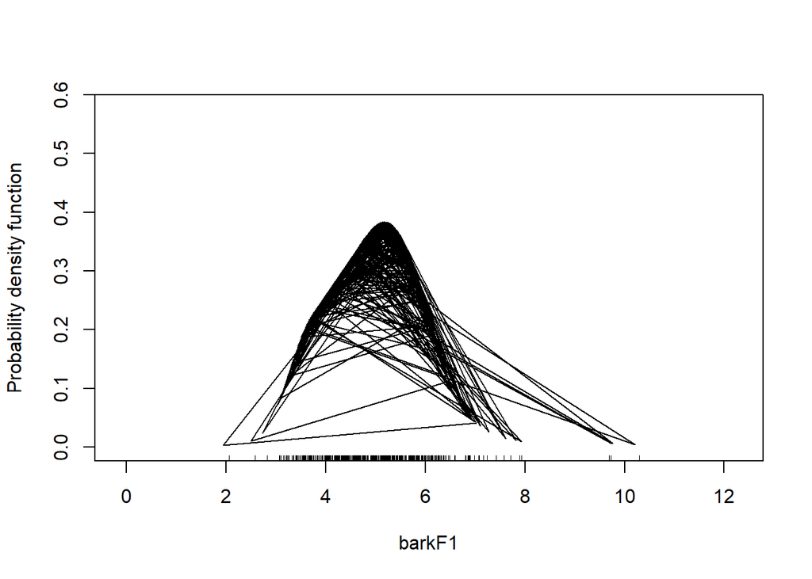

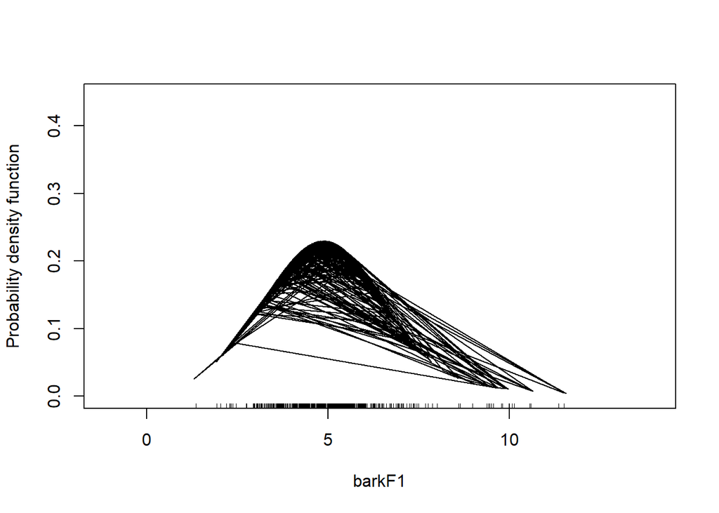

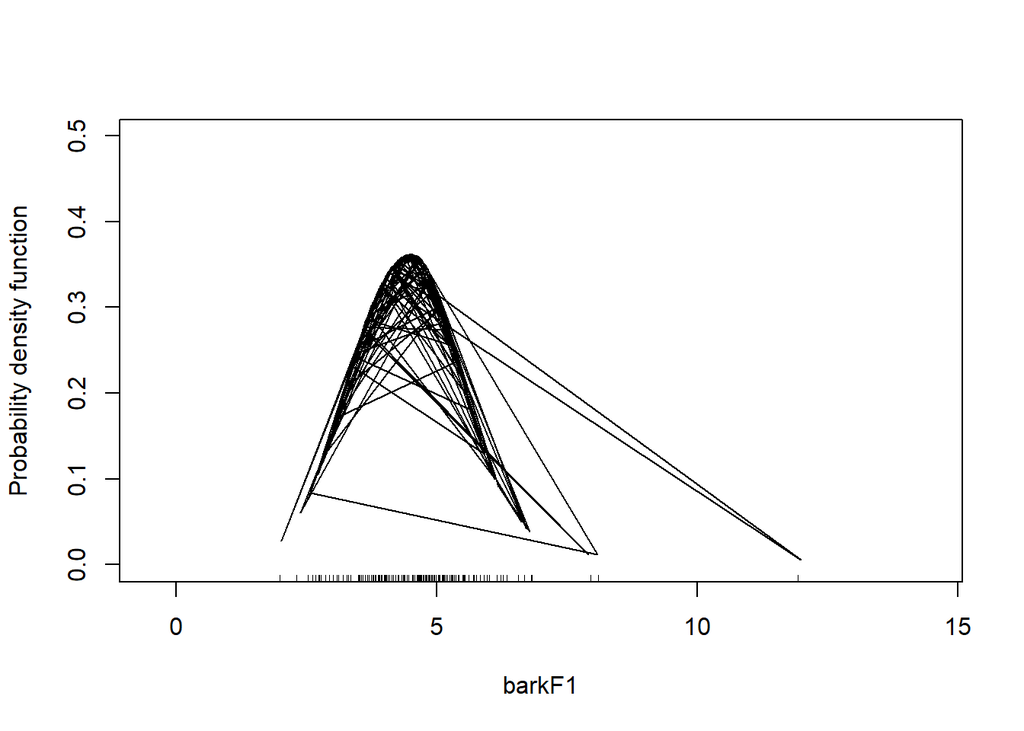

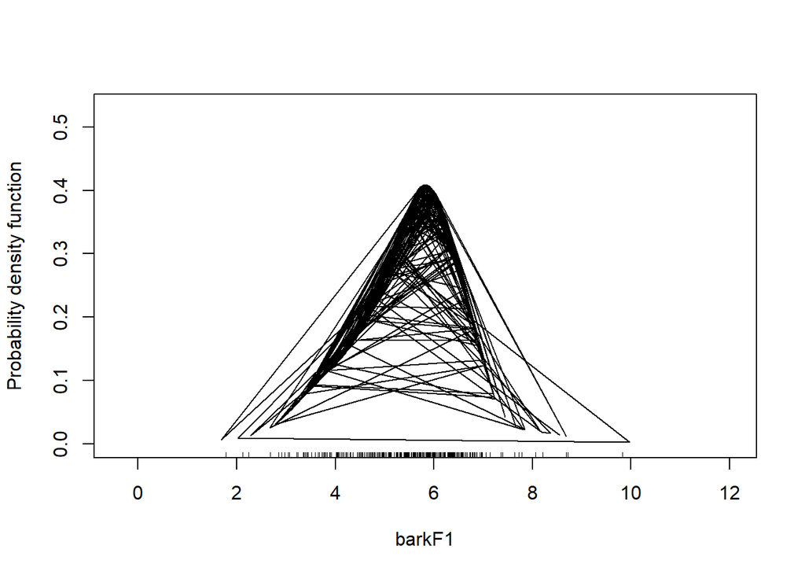

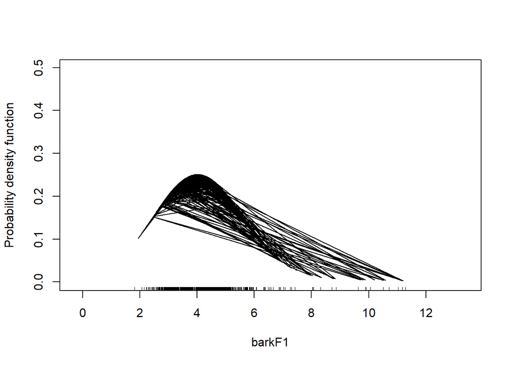

[16 more figures not shown]

```r
# inspect
nrow(fdat); head(fdat); summary(fdat$densF1)
```

```
## [1] 10754
```

```
## # A tibble: 6 × 40
## # Groups:   type, tvariety, label [4]
##   id     tmin  tmax label word  file      midpoint    F1    F2    F3 vowel type
##   <chr> <dbl> <dbl> <chr> <chr> <chr>        <dbl> <dbl> <dbl> <dbl> <chr> <chr>
## 1 4      2.29   2.5 {     that  SM_CHN_P…     2.39  714. 1357. 2004. æ     CHN
## 2 4     15.1   15.2 u:    to    SM_CHN_P…    15.2   571. 1339. 2818. u     CHN
## 3 4     18.2   18.4 u:    to    SM_CHN_P…    18.3   533. 1117. 2053. u     CHN
## 4 8     20.4   20.5 i:    we    SM_CHN_P…    20.5   497. 2031. 3021. i     CHN
## 5 8     24.2   24.3 I     with  SM_CHN_P…    24.2   439  1234. 2660. ɪ     CHN
## 6 4     35.4   35.5 I     we    SM_CHN_P…    35.5   663. 1165. 1936  ɪ     CHN
## # ℹ 28 more variables: speaker <chr>, tgender <chr>, tformants <chr>,
## #   tvariety <chr>, Code <chr>, Country <chr>, gender <chr>, Age <int>,
## #   Listening <chr>, Speaking <chr>, Pronunciation <chr>, prof <fct>,
## #   target_f1 <dbl>, target_f2 <dbl>, target_f3 <dbl>, edist <dbl>,
## #   barkF1 <dbl>, barkF2 <dbl>, fspeaker <chr>, lobF1 <dbl[,1]>,
## #   lobF2 <dbl[,1]>, remove <chr>, duration <dbl>, cutoff_duration <dbl>,
## #   densF1 <dbl>, densF2 <dbl>, qnt1F1 <dbl>, qnt1F2 <dbl>
```

```
##          Min.       1st Qu.        Median          Mean       3rd Qu.
## 0.00182742467 0.18116442385 0.21473286715 0.20872350600 0.24204877884
##          Max.
## 0.40872577746
```

```r
fdat <- fdat %>%
  # remove data point within the lowest 25 percent of densities among F1 and F2 values
  # but when label = A: and tvariety is gb
  dplyr::mutate(rmv = ifelse(label == "A:" & tvariety == "gb", "keep", "remove")) %>%
  dplyr::rowwise() %>%
  dplyr::filter(rmv == "keep" | densF1 > qnt1F1 | densF2 > qnt1F2) %>%
  # remove superfluous columns
  dplyr::select(-densF1, -densF2, -qnt1F1, -qnt1F2, -cutoff_duration, -rmv)
# inspect
head(fdat); nrow(fdat)
```

```
## # A tibble: 6 × 35
## # Rowwise:  label, type, tvariety
##   id     tmin  tmax label word  file      midpoint    F1    F2    F3 vowel type
##   <chr> <dbl> <dbl> <chr> <chr> <chr>        <dbl> <dbl> <dbl> <dbl> <chr> <chr>
## 1 4      2.29   2.5 {     that  SM_CHN_P…     2.39  714. 1357. 2004. æ     CHN
## 2 4     15.1   15.2 u:    to    SM_CHN_P…    15.2   571. 1339. 2818. u     CHN
## 3 8     24.2   24.3 I     with  SM_CHN_P…    24.2   439  1234. 2660. ɪ     CHN
## 4 4     36.7   36.8 u:    to    SM_CHN_P…    36.8   459.  682  2294. u     CHN
## 5 4     39.2   39.3 I     with  SM_CHN_P…    39.2   479.  996. 2239. ɪ     CHN
## 6 8     45.7   45.7 u:    do    SM_CHN_P…    45.7   508. 1238. 2773. u     CHN
## # ℹ 23 more variables: speaker <chr>, tgender <chr>, tformants <chr>,
## #   tvariety <chr>, Code <chr>, Country <chr>, gender <chr>, Age <int>,
## #   Listening <chr>, Speaking <chr>, Pronunciation <chr>, prof <fct>,
## #   target_f1 <dbl>, target_f2 <dbl>, target_f3 <dbl>, edist <dbl>,
## #   barkF1 <dbl>, barkF2 <dbl>, fspeaker <chr>, lobF1 <dbl[,1]>,
## #   lobF2 <dbl[,1]>, remove <chr>, duration <dbl>
```

```
## [1] 8122
```

# Remove GB target

```r
fdat <- fdat %>%
  dplyr::filter(tvariety != "gb")
```

# Normalization

See [here](https://marissabarlaz.github.io/portfolio/vowelnormalization/)

Gender normalization

```r
# Using mean F3 of open vowels (vowels with F1>600) to approximate female F1&F2 to those of male
tempvowel <- fdat %>%
  dplyr::filter(F1 > 600) %>%
  dplyr::group_by(gender) %>%
  dplyr::mutate(meanF3 = mean(F3))
# extract k: k = ratio of Female F3 to Male F3
k <- max(tempvowel$meanF3) / min(tempvowel$meanF3)
# perform normalization
fdat <- fdat %>%
  dplyr::mutate(barkF1 = phonR::normBark(F1),
                barkF2 = phonR::normBark(F2)) %>%
  dplyr::mutate(normF1 = dplyr::if_else(gender == "f", F1*k, F1),
                normF2 = dplyr::if_else(gender == "f", F2*k, F2))
```

calculate distance from target vowel centroid for each token

```r
tcentroid <- fdat %>%
  dplyr::filter(type == "ENS") %>%
  dplyr::group_by(tvariety, vowel) %>%
  dplyr::summarise(cF1 = median(barkF1),
                   cF2 = median(barkF2))
# inspect
head(tcentroid)
```

```
## # A tibble: 6 × 4
## # Groups:   tvariety [1]
##   tvariety vowel   cF1   cF2
##   <chr>    <chr> <dbl> <dbl>
## 1 us       i      4.09  12.8
## 2 us       u      4.20  10.8
## 3 us       æ      5.96  10.8
## 4 us       ɛ      5.05  11.1
## 5 us       ɪ      5.04  11.5
## 6 us       ʊ      4.43  10.9
```

combine

```r
fdat <- dplyr::left_join(fdat, tcentroid) %>%
  # euclidean distance
  dplyr::rowwise() %>%
  dplyr::mutate(ED = sqrt((barkF1-cF1)^2 + (barkF2-cF2)^2)) %>%
  # remove superfluous columns
  dplyr::select(-remove)
# inspect
head(fdat)
```

```
## # A tibble: 6 × 39
## # Rowwise:
##   id     tmin  tmax label word  file      midpoint    F1    F2    F3 vowel type
##   <chr> <dbl> <dbl> <chr> <chr> <chr>        <dbl> <dbl> <dbl> <dbl> <chr> <chr>
## 1 4      2.29   2.5 {     that  SM_CHN_P…     2.39  714. 1357. 2004. æ     CHN
## 2 4     15.1   15.2 u:    to    SM_CHN_P…    15.2   571. 1339. 2818. u     CHN
## 3 8     24.2   24.3 I     with  SM_CHN_P…    24.2   439  1234. 2660. ɪ     CHN
## 4 4     36.7   36.8 u:    to    SM_CHN_P…    36.8   459.  682  2294. u     CHN
## 5 4     39.2   39.3 I     with  SM_CHN_P…    39.2   479.  996. 2239. ɪ     CHN
## 6 8     45.7   45.7 u:    do    SM_CHN_P…    45.7   508. 1238. 2773. u     CHN
## # ℹ 27 more variables: speaker <chr>, tgender <chr>, tformants <chr>,
## #   tvariety <chr>, Code <chr>, Country <chr>, gender <chr>, Age <int>,
## #   Listening <chr>, Speaking <chr>, Pronunciation <chr>, prof <fct>,
## #   target_f1 <dbl>, target_f2 <dbl>, target_f3 <dbl>, edist <dbl>,
## #   barkF1 <dbl>, barkF2 <dbl>, fspeaker <chr>, lobF1 <dbl[,1]>,
## #   lobF2 <dbl[,1]>, duration <dbl>, normF1 <dbl>, normF2 <dbl>, cF1 <dbl>,
## #   cF2 <dbl>, ED <dbl>
```

# Gramm. Status of Word

```r
gram <- c("be", "but", "did", "do", "get", "gets", "got", "had", "has", "he", "his",
          "she", "that", "this", "too", "was", "we", "what", "who", "with")
fdat <- fdat %>%
  # gramm. category of word
  dplyr::mutate(WordType = ifelse(word %in% gram, "grammatical", "lexical"))
```

remove superfluous variables

```r
fdat <- fdat %>%
  dplyr::select(id, label, word, file, F1, F2, speaker, vowel,
                label, type, gender, Age, tvariety, edist, barkF1,
                barkF2, fspeaker, lobF1, lobF2, duration, normF1,
                normF2, cF1, cF2, ED, WordType, prof) %>%
  # create new speaker column
  dplyr::mutate(speaker = paste0(type, speaker))
# inspect
head(fdat)
```

```
## # A tibble: 6 × 26
## # Rowwise:
##   id    label word  file      F1    F2 speaker vowel type  gender   Age tvariety
##   <chr> <chr> <chr> <chr>  <dbl> <dbl> <chr>   <chr> <chr> <chr>  <int> <chr>
## 1 4     {     that  SM_CH…  714. 1357. CHN001  æ     CHN   male      20 us
## 2 4     u:    to    SM_CH…  571. 1339. CHN001  u     CHN   male      20 us
## 3 8     I     with  SM_CH…  439  1234. CHN001  ɪ     CHN   male      20 us
## 4 4     u:    to    SM_CH…  459.  682  CHN001  u     CHN   male      20 us
## 5 4     I     with  SM_CH…  479.  996. CHN001  ɪ     CHN   male      20 us
## 6 8     u:    do    SM_CH…  508. 1238. CHN001  u     CHN   male      20 us
## # ℹ 14 more variables: edist <dbl>, barkF1 <dbl>, barkF2 <dbl>, fspeaker <chr>,
## #   lobF1 <dbl[,1]>, lobF2 <dbl[,1]>, duration <dbl>, normF1 <dbl>,
## #   normF2 <dbl>, cF1 <dbl>, cF2 <dbl>, ED <dbl>, WordType <chr>, prof <fct>
```

## Save data

```r
# save
base::saveRDS(fdat, file = here::here("data", "cleandat.rda"))
```

# Citation & Session Info

Schweinberger, Martin. 2024. Using machine-learning to analyse English vowels produced by Chinese learners of English.